# Practical Machine Learning - Week 3 Course Project

### Background and Objective

##### 6 participants in a fitness project are asked to perform barbell lifts correctly and incorrectly in 5 different ways.The data is collected from accelerometers on the belt, forearm, arm, and dumbell of the participants.

##### The goal is to predict the manner in which they did the exercise.

### Pulling the Data

##### Download the training and testing data from the given data sources links

```r
download.file("http://d396qusza40orc.cloudfront.net/predmachlearn/pml-training.csv",destfile="./acctrain.csv")

download.file("http://d396qusza40orc.cloudfront.net/predmachlearn/pml-testing.csv",destfile="./acctest.csv")
```

##### Read the training and testing data from Working Directory.

```r
acctrain<-read.csv("acctrain.csv",na.strings=c("NA","#DIV/0!",""))

acctest<-read.csv("acctest.csv",na.strings=c("NA","#DIV/0!",""))
```

### Explore and Clean Data

##### Training dataset has 19622 records and 160 columns and test dataset has 20 records and 160 columns.

```r
colNA<-colMeans(is.na(acctrain))
```

##### Lots of columns in the traing data have NA (missings) percentage greater than 97%. Imputing for missing values in these cases are futile so should remove these columns.

```r
acctrain2<-acctrain[,colMeans(is.na(acctrain))<.97]
```

##### After removing columns with high no. of missing values, Training dataset has 19622 records and 60 columns.

##### Same operation on test data, Testing dataset has 20 records and 60 columns.

```r
acctest2<-acctest[,colMeans(is.na(acctest))<.97]
```

#### Keeping only the accelerometer related data in the training and test datasets. According to problem statement - ‘your goal will be to use data from accelerometers on the belt, forearm, arm, and dumbell of 6 participants’

##### Note that dropping the ‘Problem_ID’ column from testing dataset as it is not required.

```r
acctrain3<-acctrain2[,c(grep("belt|forearm|arm|dumbbell",names(acctrain2)),ncol(acctrain2))]

acctest3<-acctest2[,c(grep("belt|forearm|arm|dumbbell",names(acctest2)))]
```

### Creating Training Data Partition to create a Cross-Validation Dataset using Caret library

##### Creating a 60%-40% split

```r
library(caret)
set.seed(15390)

inTrain <- createDataPartition(acctrain3$classe, p = .6, list=FALSE)
trainingdata <- acctrain3[inTrain,]
testingdata <- acctrain3[-inTrain,]
```

### Training the Model on 60% data

##### Run the Random Forest model using the reduced set of predictors to predict the ‘classe’ variable and evaluate how well it works predicting the training sample

```r
library(randomForest)
```

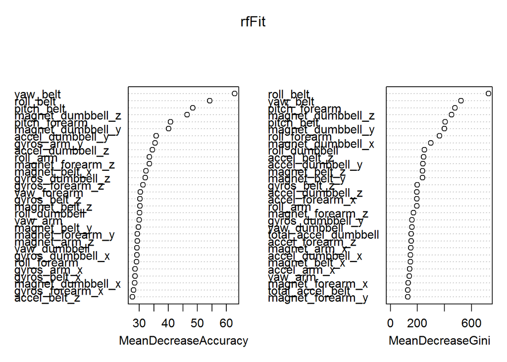

```r
trctrl=trainControl(method="cv",10,repeats=5)

rfFit <- randomForest(classe ~.,
                       trControl=trctrl,
                       data=trainingdata,
                       ntree=500,
                       imp=TRUE)

varImpPlot(rfFit)
```

```r
trpred <- predict(rfFit, trainingdata)

confusionMatrix( trainingdata$classe,trpred)
```

```
## Confusion Matrix and Statistics
##
##           Reference
## Prediction    A    B    C    D    E
##          A 3348    0    0    0    0
##          B    0 2279    0    0    0
##          C    0    0 2054    0    0
##          D    0    0    0 1930    0
##          E    0    0    0    0 2165
##
## Overall Statistics
##
##                Accuracy : 1
##                  95% CI : (0.9997, 1)
##     No Information Rate : 0.2843
##     P-Value [Acc > NIR] : < 2.2e-16
##
##                   Kappa : 1
##  Mcnemar's Test P-Value : NA
##
## Statistics by Class:
##
##                      Class: A Class: B Class: C Class: D Class: E
## Sensitivity            1.0000   1.0000   1.0000   1.0000   1.0000
## Specificity            1.0000   1.0000   1.0000   1.0000   1.0000
## Pos Pred Value         1.0000   1.0000   1.0000   1.0000   1.0000
## Neg Pred Value         1.0000   1.0000   1.0000   1.0000   1.0000
## Prevalence             0.2843   0.1935   0.1744   0.1639   0.1838
## Detection Rate         0.2843   0.1935   0.1744   0.1639   0.1838
## Detection Prevalence   0.2843   0.1935   0.1744   0.1639   0.1838
## Balanced Accuracy      1.0000   1.0000   1.0000   1.0000   1.0000
```

#### Accuracy of the model on training data looks good, now time for validating it on the hold-out sample.

### Validate the Model on 40% data

##### Fit the hold-out validation sample with the training RF model

```r
testpred <- predict(rfFit, testingdata)

confusionMatrix( testingdata$classe, testpred)
```

```
## Confusion Matrix and Statistics
##
##           Reference
## Prediction    A    B    C    D    E
##          A 2231    1    0    0    0
##          B   11 1504    3    0    0
##          C    0   10 1358    0    0
##          D    0    0   18 1266    2
##          E    0    0    0    4 1438
##
## Overall Statistics
##
##                Accuracy : 0.9938
##                  95% CI : (0.9918, 0.9954)
##     No Information Rate : 0.2858
##     P-Value [Acc > NIR] : < 2.2e-16
##
##                   Kappa : 0.9921
##  Mcnemar's Test P-Value : NA
##
## Statistics by Class:
##
##                      Class: A Class: B Class: C Class: D Class: E
## Sensitivity            0.9951   0.9927   0.9848   0.9969   0.9986
## Specificity            0.9998   0.9978   0.9985   0.9970   0.9994
## Pos Pred Value         0.9996   0.9908   0.9927   0.9844   0.9972
## Neg Pred Value         0.9980   0.9983   0.9968   0.9994   0.9997
## Prevalence             0.2858   0.1931   0.1758   0.1619   0.1835
## Detection Rate         0.2843   0.1917   0.1731   0.1614   0.1833
## Detection Prevalence   0.2845   0.1935   0.1744   0.1639   0.1838
## Balanced Accuracy      0.9975   0.9953   0.9916   0.9969   0.9990
```

#### Obtained accuracy of 99.38%, which means an error of 0.62% in the hold-out sample. The model looks good enough to use on the 20 test data points.

### Predict the classe for the 20 test sample

```r
finaltestpred <- as.character(predict(rfFit, acctest3))


pml_write_files = function(x){
  n = length(x)
  for(i in 1:n){
    filename = paste0("problem_id_",i,".txt")
    write.table(x[i],file=filename,quote=FALSE,row.names=FALSE,col.names=FALSE)
  }
}

pml_write_files(finaltestpred)
```